# Bài tập 02 từ 1 -> 8

# Bài 1

Hướng gió thổi theo hướng Bắc–Nam từ buổi sáng đến buổi trưa. Sau đó nó đổi hướng sang Đông–Tây. Thời điểm giữa trưa được xem là giai đoạn chuyển tiếp của sự thay đổi hướng gió từ Bắc–Nam sang Đông–Tây như trong Hình P2.1.

## Hình minh họa

[figure not shown]

## Yêu cầu

Tìm:

- Phép giao, hợp, hiệu của hai hướng gió

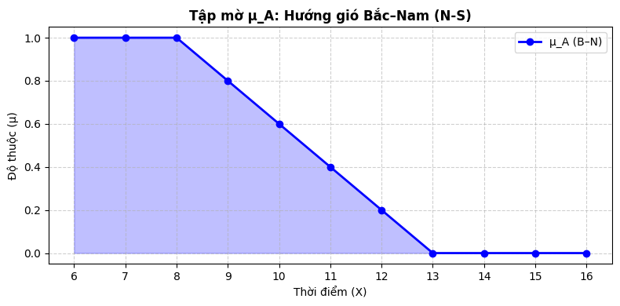

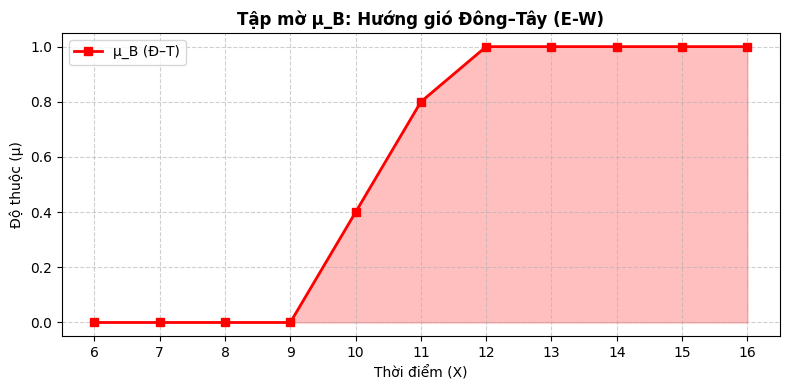

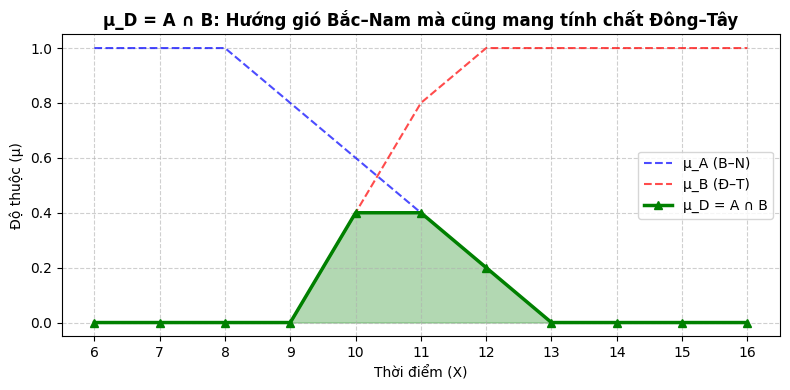

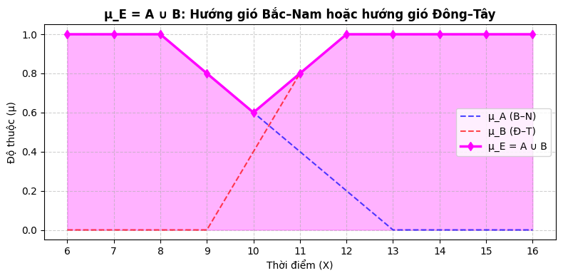

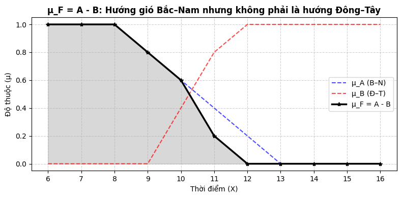

```python
import numpy as np
import matplotlib.pyplot as plt

# ===== 1. KHÔNG GIAN NỀN =====
X = np.array([6, 7, 8, 9, 10, 11, 12, 13, 14, 15, 16], dtype=float)

# ===== 2. TẬP MỜ GỐC =====
muA = np.array([1.0, 1.0, 1.0, 0.8, 0.6, 0.4, 0.2, 0.0, 0.0, 0.0, 0.0])  # μ_A: Hướng gió B-N
muB = np.array([0.0, 0.0, 0.0, 0.0, 0.4, 0.8, 1.0, 1.0, 1.0, 1.0, 1.0])  # μ_B: Hướng gió Đ-T

# ===== 3. TẬP MỜ THEO PHÉP TOÁN MỜ =====
muD = np.minimum(muA, muB)           # D = A ∩ B
muE = np.maximum(muA, muB)           # E = A ∪ B
muF = np.minimum(muA, 1 - muB)       # F = A - B (A ∩ B^c)

# ===== 4. CẤU HÌNH CHUNG =====
plt.rcParams['axes.unicode_minus'] = False  # Hiển thị dấu trừ đúng
markers = {'A':'o', 'B':'s', 'D':'^', 'E':'d', 'F':'*'}  # Marker khác nhau cho từng đồ thị

# ===== 5. VẼ TỪNG ĐỒ THỊ =====

# --- Đồ thị A: μ_A (Bắc–Nam) ---
plt.figure(figsize=(8, 4))
plt.plot(X, muA, color='blue', marker=markers['A'], linestyle='-', linewidth=2, label='μ_A (B–N)')
plt.fill_between(X, muA, 0, alpha=0.25, color='blue')
plt.title("Tập mờ μ_A: Hướng gió Bắc–Nam (N-S)", fontsize=12, fontweight='bold')
plt.xlabel("Thời điểm (X)"); plt.ylabel("Độ thuộc (μ)")
plt.xticks(X); plt.yticks(np.arange(0, 1.1, 0.2)); plt.grid(True, linestyle='--', alpha=0.6)
plt.legend(); plt.tight_layout(); plt.show()

# --- Đồ thị B: μ_B (Đông–Tây) ---
plt.figure(figsize=(8, 4))
plt.plot(X, muB, color='red', marker=markers['B'], linestyle='-', linewidth=2, label='μ_B (Đ–T)')
plt.fill_between(X, muB, 0, alpha=0.25, color='red')
plt.title("Tập mờ μ_B: Hướng gió Đông–Tây (E-W)", fontsize=12, fontweight='bold')
plt.xlabel("Thời điểm (X)"); plt.ylabel("Độ thuộc (μ)")
plt.xticks(X); plt.yticks(np.arange(0, 1.1, 0.2)); plt.grid(True, linestyle='--', alpha=0.6)
plt.legend(); plt.tight_layout(); plt.show()

# --- Đồ thị D = A ∩ B ---
plt.figure(figsize=(8, 4))
plt.plot(X, muA, 'b--', label='μ_A (B–N)', alpha=0.7)
plt.plot(X, muB, 'r--', label='μ_B (Đ–T)', alpha=0.7)
plt.plot(X, muD, color='green', marker=markers['D'], linestyle='-', linewidth=2.5, label='μ_D = A ∩ B')
plt.fill_between(X, muD, 0, alpha=0.3, color='green')
plt.title("μ_D = A ∩ B: Hướng gió Bắc–Nam mà cũng mang tính chất Đông–Tây", fontsize=12, fontweight='bold')
plt.xlabel("Thời điểm (X)"); plt.ylabel("Độ thuộc (μ)")
plt.xticks(X); plt.yticks(np.arange(0, 1.1, 0.2)); plt.grid(True, linestyle='--', alpha=0.6)
plt.legend(); plt.tight_layout(); plt.show()

# --- Đồ thị E = A ∪ B ---
plt.figure(figsize=(8, 4))
plt.plot(X, muA, 'b--', label='μ_A (B–N)', alpha=0.7)
plt.plot(X, muB, 'r--', label='μ_B (Đ–T)', alpha=0.7)
plt.plot(X, muE, color='magenta', marker=markers['E'], linestyle='-', linewidth=2.5, label='μ_E = A ∪ B')
plt.fill_between(X, muE, 0, alpha=0.3, color='magenta')
plt.title("μ_E = A ∪ B: Hướng gió Bắc–Nam hoặc hướng gió Đông–Tây", fontsize=12, fontweight='bold')
plt.xlabel("Thời điểm (X)"); plt.ylabel("Độ thuộc (μ)")
plt.xticks(X); plt.yticks(np.arange(0, 1.1, 0.2)); plt.grid(True, linestyle='--', alpha=0.6)
plt.legend(); plt.tight_layout(); plt.show()

# --- Đồ thị F = A - B ---
plt.figure(figsize=(8, 4))
plt.plot(X, muA, 'b--', label='μ_A (B–N)', alpha=0.7)
plt.plot(X, muB, 'r--', label='μ_B (Đ–T)', alpha=0.7)
plt.plot(X, muF, color='black', marker=markers['F'], linestyle='-', linewidth=2.5, label='μ_F = A - B')
plt.fill_between(X, muF, 0, alpha=0.3, color='gray')
plt.title("μ_F = A - B: Hướng gió Bắc–Nam nhưng không phải là hướng Đông–Tây", fontsize=12, fontweight='bold')
plt.xlabel("Thời điểm (X)"); plt.ylabel("Độ thuộc (μ)")
plt.xticks(X); plt.yticks(np.arange(0, 1.1, 0.2)); plt.grid(True, linestyle='--', alpha=0.6)
plt.legend(); plt.tight_layout(); plt.show()
```

# Bài 2:

So sánh độ bền kéo của hai loại thép bằng tập mờ

Hai loại thép được kiểm tra độ bền kéo bốn lần cho mỗi loại. Xét các tập mờ $\tilde{A}$ và $\tilde{B}$ đại diện cho hai loại thép trên không gian độ bền kéo (không có đơn vị), trong đó bốn phép thử: $$X = \{1, 2, 3, 4\}$$ được thực hiện cho mỗi loại thép.

Các tập mờ sau biểu diễn độ bền kéo của mỗi loại thép: $$\tilde{A} = 0.4/1 + 0.35/2 + 0.5/3 + 0.6/4$$ $$\tilde{B} = 0.7/1 + 0.75/2 + 0.65/3 + 0.8/4$$

So sánh độ bền kéo của hai loại thép bằng cách tìm:

- $\tilde{A} \cup \tilde{B}$
- $\tilde{A} \cap \tilde{B}$
- $\overline{\tilde{A}}, \overline{\tilde{B}}$
- $\tilde{A} - \tilde{B}$

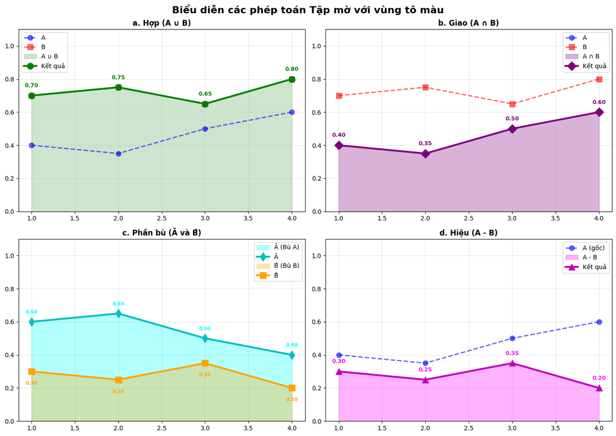

```python
import matplotlib.pyplot as plt
import numpy as np

# 1. Dữ liệu đầu vào
x = np.array([1, 2, 3, 4])
y_A = np.array([0.4, 0.35, 0.5, 0.6])
y_B = np.array([0.7, 0.75, 0.65, 0.8])

# 2. Tính toán các tập mờ kết quả
y_union = np.maximum(y_A, y_B)        # Hợp
y_inter = np.minimum(y_A, y_B)        # Giao
y_comp_A = 1 - y_A                     # Bù A
y_comp_B = 1 - y_B                     # Bù B
y_diff = np.minimum(y_A, y_comp_B)    # Hiệu A - B

# Tạo mảng x mở rộng để fill_between hoạt động tốt hơn
x_extended = np.array([1, 2, 3, 4])

# 3. Thiết lập khung hình (2 hàng, 2 cột)
fig, axes = plt.subplots(2, 2, figsize=(14, 10))
fig.suptitle('Biểu diễn các phép toán Tập mờ với vùng tô màu', fontsize=16, fontweight='bold')

# --- Ô 1: Phép Hợp (Union) ---
axes[0, 0].set_title('a. Hợp (A ∪ B)', fontsize=12, fontweight='bold')
axes[0, 0].set_ylim(0, 1.1)

# Vẽ đường nối các điểm của A và B
axes[0, 0].plot(x_extended, y_A, 'b--o', linewidth=2, markersize=8, label='A', alpha=0.6)
axes[0, 0].plot(x_extended, y_B, 'r--s', linewidth=2, markersize=8, label='B', alpha=0.6)

# Tô vùng hợp (vùng cao hơn)
axes[0, 0].fill_between(x_extended, 0, y_union, alpha=0.2, color='green', label='A ∪ B')

# Vẽ đường nét liền cho kết quả hợp
axes[0, 0].plot(x_extended, y_union, 'g-', linewidth=3, markersize=10, marker='o', label='Kết quả')

# Thêm nhãn giá trị
for i, txt in enumerate(y_union):
    axes[0, 0].annotate(f'{txt:.2f}', (x_extended[i], y_union[i]+0.05),
                       ha='center', fontsize=9, fontweight='bold', color='green')

axes[0, 0].legend()
axes[0, 0].grid(True, alpha=0.3)

# --- Ô 2: Phép Giao (Intersection) ---
axes[0, 1].set_title('b. Giao (A ∩ B)', fontsize=12, fontweight='bold')
axes[0, 1].set_ylim(0, 1.1)

# Vẽ đường nối các điểm của A và B
axes[0, 1].plot(x_extended, y_A, 'b--o', linewidth=2, markersize=8, label='A', alpha=0.6)
axes[0, 1].plot(x_extended, y_B, 'r--s', linewidth=2, markersize=8, label='B', alpha=0.6)

# Tô vùng giao (vùng thấp hơn)
axes[0, 1].fill_between(x_extended, 0, y_inter, alpha=0.3, color='purple', label='A ∩ B')

# Vẽ đường nét liền cho kết quả giao
axes[0, 1].plot(x_extended, y_inter, 'purple', linewidth=3, markersize=10, marker='D', label='Kết quả')

# Thêm nhãn giá trị
for i, txt in enumerate(y_inter):
    axes[0, 1].annotate(f'{txt:.2f}', (x_extended[i], y_inter[i]+0.05),
                       ha='center', fontsize=9, fontweight='bold', color='purple')

axes[0, 1].legend()
axes[0, 1].grid(True, alpha=0.3)

# --- Ô 3: Phần Bù (Complement) ---
axes[1, 0].set_title('c. Phần bù (Ā và B̄)', fontsize=12, fontweight='bold')
axes[1, 0].set_ylim(0, 1.1)

# Tô vùng bù của A
axes[1, 0].fill_between(x_extended, 0, y_comp_A, alpha=0.3, color='cyan', label='Ā (Bù A)')
axes[1, 0].plot(x_extended, y_comp_A, 'c-', linewidth=3, markersize=10, marker='d', label='Ā')

# Tô vùng bù của B
axes[1, 0].fill_between(x_extended, 0, y_comp_B, alpha=0.3, color='orange', label='B̄ (Bù B)')
axes[1, 0].plot(x_extended, y_comp_B, 'orange', linewidth=3, markersize=10, marker='s', label='B̄')

# Thêm nhãn giá trị cho Ā
for i, txt in enumerate(y_comp_A):
    axes[1, 0].annotate(f'{txt:.2f}', (x_extended[i], y_comp_A[i]+0.05),
                       ha='center', fontsize=8, fontweight='bold', color='cyan')

# Thêm nhãn giá trị cho B̄
for i, txt in enumerate(y_comp_B):
    axes[1, 0].annotate(f'{txt:.2f}', (x_extended[i], y_comp_B[i]-0.08),
                       ha='center', fontsize=8, fontweight='bold', color='orange')

axes[1, 0].legend()
axes[1, 0].grid(True, alpha=0.3)

# --- Ô 4: Hiệu (Difference) ---
axes[1, 1].set_title('d. Hiệu (A - B)', fontsize=12, fontweight='bold')
axes[1, 1].set_ylim(0, 1.1)

# Vẽ đường của A gốc
axes[1, 1].plot(x_extended, y_A, 'b--o', linewidth=2, markersize=8, label='A (gốc)', alpha=0.6)

# Tô vùng hiệu
axes[1, 1].fill_between(x_extended, 0, y_diff, alpha=0.3, color='magenta', label='A - B')

# Vẽ đường nét liền cho kết quả hiệu
axes[1, 1].plot(x_extended, y_diff, 'm-', linewidth=3, markersize=10, marker='^', label='Kết quả')

# Thêm nhãn giá trị
for i, txt in enumerate(y_diff):
    axes[1, 1].annotate(f'{txt:.2f}', (x_extended[i], y_diff[i]+0.05),
                       ha='center', fontsize=9, fontweight='bold', color='magenta')

axes[1, 1].legend()
axes[1, 1].grid(True, alpha=0.3)

# Điều chỉnh khoảng cách giữa các ô
plt.tight_layout()
plt.show()
```

# Bài 3

Phân tích tập mờ trong đánh giá khả năng sinh lợi của doanh nghiệp

Trong việc xác định khả năng sinh lợi của doanh nghiệp, nhiều công ty xây dựng phải đưa ra quyết định dựa trên thói quen chi tiêu của khách hàng, chẳng hạn như số tiền khách hàng chi tiêu và khả năng chi tiêu của họ. Nhiều thuộc tính trong số này mang tính mờ.

Một khách hàng chi tiêu “một khoản lớn” được xem là “có lợi nhuận” đối với công ty xây dựng. “Khoản lớn” là một biến mờ, và “lợi nhuận” cũng là một biến mờ.

Hai tập mờ này nên có một phần giao nhau, nhưng không nên được định nghĩa trên cùng một miền giá trị.

- $\tilde{A} = \{\text{khách hàng chi tiêu lớn}\}$
- $\tilde{B} = \{\text{khách hàng có lợi nhuận}\}$

[figure not shown]

Đối với hai tập mờ trong Hình P2.3, hãy tìm bằng đồ họa: a. $\tilde{A} \cup \tilde{B}$: tất cả khách hàng được xem là có lợi nhuận hoặc chi tiêu lớn. b. $\tilde{A} \cap \tilde{B}$: tất cả khách hàng vừa có lợi nhuận vừa chi tiêu lớn. c. $\overline{\tilde{A}}$ và $\overline{\tilde{B}}$: những khách hàng (i) không có lợi nhuận và (ii) không phải khách hàng chi tiêu lớn. d. $\tilde{A} - \tilde{B}$: các khách hàng có lợi nhuận nhưng không phải khách hàng chi tiêu lớn. e. $\overline{\tilde{A} \cup \tilde{B}} = \overline{\tilde{A}} \cap \overline{\tilde{B}}$ (nguyên lý De Morgan).

[output not shown]

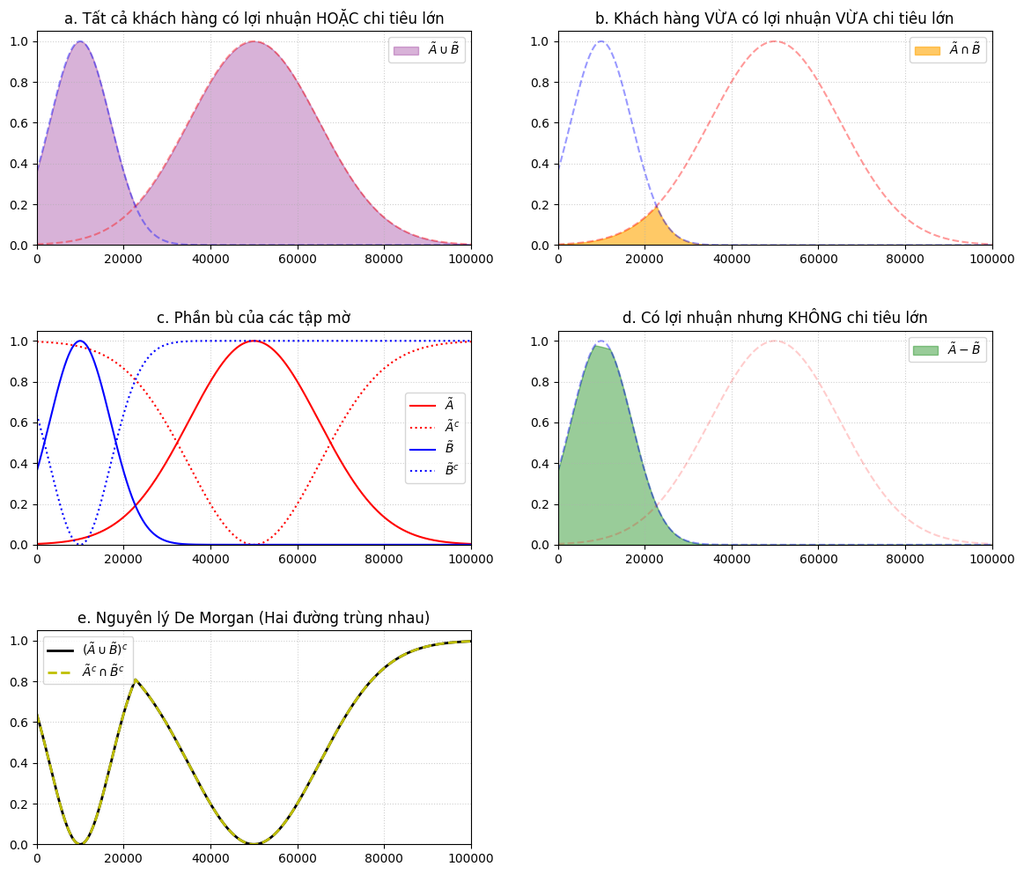

```python
import numpy as np
import matplotlib.pyplot as plt

# 1. Định nghĩa không gian nền x (Số tiền từ 0 đến 100,000)
x = np.linspace(0, 100000, 1000)

# 2. Định nghĩa hàm thuộc cho các tập mờ cơ sở
# Tập B: Khách hàng có lợi nhuận (đỉnh tại 10,000)
mu_B = np.exp(-0.5 * ((x - 10000) / 7000)**2)

# Tập A: Khách hàng chi tiêu lớn (đỉnh tại 50,000)
mu_A = np.exp(-0.5 * ((x - 50000) / 15000)**2)

# 3. Tính toán các phép toán tập mờ
mu_union = np.maximum(mu_A, mu_B)             # a. A U B (Hợp)
mu_inter = np.minimum(mu_A, mu_B)             # b. A ∩ B (Giao)
mu_not_A = 1 - mu_A                           # c. Bù A
mu_not_B = 1 - mu_B                           # c. Bù B
mu_diff  = np.minimum(mu_B, 1 - mu_A)          # d. B - A (Hiệu)
mu_de_morgan_lhs = 1 - mu_union               # e. vế trái De Morgan
mu_de_morgan_rhs = np.minimum(mu_not_A, mu_not_B) # e. vế phải De Morgan

# 4. Vẽ đồ thị
fig, axes = plt.subplots(3, 2, figsize=(14, 12))
plt.subplots_adjust(hspace=0.4, wspace=0.2)

# Câu a: Phép hợp
axes[0, 0].plot(x, mu_A, 'r--', alpha=0.4)
axes[0, 0].plot(x, mu_B, 'b--', alpha=0.4)
axes[0, 0].fill_between(x, mu_union, color='purple', alpha=0.3, label='$\~{A} \cup \~{B}$')
axes[0, 0].set_title("a. Tất cả khách hàng có lợi nhuận HOẶC chi tiêu lớn")
axes[0, 0].legend()

# Câu b: Phép giao
axes[0, 1].plot(x, mu_A, 'r--', alpha=0.4)
axes[0, 1].plot(x, mu_B, 'b--', alpha=0.4)
axes[0, 1].fill_between(x, mu_inter, color='orange', alpha=0.6, label='$\~{A} \cap \~{B}$')
axes[0, 1].set_title("b. Khách hàng VỪA có lợi nhuận VỪA chi tiêu lớn")
axes[0, 1].legend()

# Câu c: Phép bù
axes[1, 0].plot(x, mu_A, 'r', label='$\~{A}$')
axes[1, 0].plot(x, mu_not_A, 'r:', label='$\~{A}^c$')
axes[1, 0].plot(x, mu_B, 'b', label='$\~{B}$')
axes[1, 0].plot(x, mu_not_B, 'b:', label='$\~{B}^c$')
axes[1, 0].set_title("c. Phần bù của các tập mờ")
axes[1, 0].legend(loc='center right')

# Câu d: Phép hiệu
axes[1, 1].plot(x, mu_A, 'r--', alpha=0.2)
axes[1, 1].plot(x, mu_B, 'b--', alpha=0.4)
axes[1, 1].fill_between(x, mu_diff, color='green', alpha=0.4, label='$\~{A} - \~{B}$')
axes[1, 1].set_title("d. Có lợi nhuận nhưng KHÔNG chi tiêu lớn")
axes[1, 1].legend()

# Câu e: Nguyên lý De Morgan
axes[2, 0].plot(x, mu_de_morgan_lhs, 'k', lw=2, label='$( \~{A} \cup \~{B} )^c$')
axes[2, 0].plot(x, mu_de_morgan_rhs, 'y--', lw=2, label='$\~{A}^c \cap \~{B}^c$')
axes[2, 0].set_title("e. Nguyên lý De Morgan (Hai đường trùng nhau)")
axes[2, 0].legend()

# Xóa subplot dư thừa
axes[2, 1].axis('off')

# Định dạng chung cho các trục
for ax in axes.flat:
    ax.set_ylim(0, 1.05)
    ax.set_xlim(0, 100000)
    ax.grid(True, linestyle=':', alpha=0.6)

plt.show()
```

# Bài 4. Kiểm tra tốc độ phương tiện giao thông

Xe máy ($\tilde{M}$), ô tô ($\tilde{C}$) và xe tải ($\tilde{T}$) được kiểm tra về tốc độ. Tốc độ bị ảnh hưởng trực tiếp bởi công suất động cơ (HP).

**Cho:** $$X = \{10, 30, 100, 200, 500\}$$

Các giá trị membership function được cho trong bảng:

[figure not shown]

**Tìm:**

1. $\tilde{M} \cup \tilde{C}$
2. $\tilde{C} \cap \tilde{T}$
3. $\overline{M}$
4. $\overline{T}$
5. $\tilde{M} - \tilde{T}$
6. $\tilde{C} \cup \tilde{T}$
7. $\tilde{M} \cap (\tilde{C} \cup \tilde{T})$

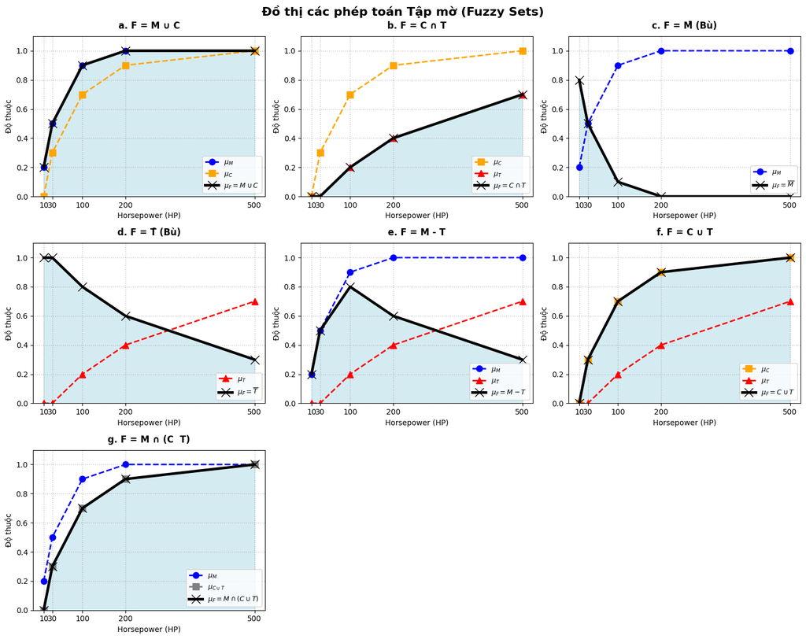

```
KẾT QUẢ TÍNH TOÁN:
a. M U C:           [0.2 0.5 0.9 1.  1. ]
b. C ∩ T:           [0.  0.  0.2 0.4 0.7]
c. M_bar:           [0.8 0.5 0.1 0.  0. ]
d. T_bar:           [1.  1.  0.8 0.6 0.3]
e. M - T:           [0.2 0.5 0.8 0.6 0.3]
f. C U T:           [0.  0.3 0.7 0.9 1. ]
g. M ∩ (C  T):     [0.  0.3 0.7 0.9 1. ]
```

```python
import matplotlib.pyplot as plt
import numpy as np

# Dữ liệu đầu vào
X = np.array([10, 30, 100, 200, 500])
M = np.array([0.2, 0.5, 0.9, 1.0, 1.0])
C = np.array([0.0, 0.3, 0.7, 0.9, 1.0])
T = np.array([0.0, 0.0, 0.2, 0.4, 0.7])

# Các phép toán Fuzzy
def fuzzy_union(A, B):
    return np.maximum(A, B)

def fuzzy_intersection(A, B):
    return np.minimum(A, B)

def fuzzy_complement(A):
    return 1 - A

def fuzzy_difference(A, B):
    return np.minimum(A, 1 - B)

# Tính toán các kết quả
res_a = fuzzy_union(M, C)
res_b = fuzzy_intersection(C, T)
res_c = fuzzy_complement(M)
res_d = fuzzy_complement(T)
res_e = fuzzy_difference(M, T)
res_f = fuzzy_union(C, T)
res_g = fuzzy_intersection(M, res_f)

# Thiết lập đồ thị
fig, axs = plt.subplots(3, 3, figsize=(15, 12))
fig.suptitle('Đồ thị các phép toán Tập mờ (Fuzzy Sets)', fontsize=16, fontweight='bold')

def plot_styled_fuzzy(ax, x, inputs, input_names, input_colors, result, result_name, title):
    """
    Hàm vẽ theo phong cách ảnh mẫu:
    - Inputs: Nét đứt, marker riêng biệt.
    - Result: Nét đen đậm, marker 'x', fill nền màu xanh nhạt.
    """

    # 1. Vẽ các tập đầu vào (Nét đứt)
    for name, data, color in zip(input_names, inputs, input_colors):
        # Marker: M dùng 'o', C dùng 's', T dùng '^' để phân biệt
        marker = 'o' if 'M' in name else ('s' if 'C' in name else '^')
        ax.plot(x, data, color=color, linestyle='--', linewidth=2, marker=marker, markersize=8, label=name)

    # 2. Vẽ tập kết quả (Nét đen đậm, Marker 'x') - Giống ảnh mẫu
    ax.plot(x, result, color='black', linewidth=3.5, marker='x', markersize=12, label=result_name)

    # 3. Tô nền phía dưới kết quả (Giống ảnh mẫu)
    ax.fill_between(x, result, color='lightblue', alpha=0.5)

    # 4. Cấu hình trục và lưới
    ax.set_title(title, fontsize=12, fontweight='bold', pad=10)
    ax.set_xlabel('Horsepower (HP)', fontsize=10)
    ax.set_ylabel('Độ thuộc', fontsize=10)
    ax.set_ylim(0, 1.1)
    ax.set_xticks(x)
    ax.grid(True, linestyle=':', linewidth=1, color='gray', alpha=0.5)
    ax.legend(loc='lower right', fontsize=9)

# --- Cấu hình từng đồ thị ---

# a. M U C
plot_styled_fuzzy(axs[0, 0], X, [M, C],
                  [r'$\mu_M$', r'$\mu_C$'], ['blue', 'orange'],
                  res_a, r'$\mu_F = M \cup C$', 'a. F = M ∪ C')

# b. C ∩ T
plot_styled_fuzzy(axs[0, 1], X, [C, T],
                  [r'$\mu_C$', r'$\mu_T$'], ['orange', 'red'],
                  res_b, r'$\mu_F = C \cap T$', 'b. F = C ∩ T')

# c. M_bar (Complement) - Chỉ có 1 input là M
plot_styled_fuzzy(axs[0, 2], X, [M],
                  [r'$\mu_M$'], ['blue'],
                  res_c, r'$\mu_F = \overline{M}$', 'c. F = M̄ (Bù)')

# d. T_bar (Complement) - Chỉ có 1 input là T
plot_styled_fuzzy(axs[1, 0], X, [T],
                  [r'$\mu_T$'], ['red'],
                  res_d, r'$\mu_F = \overline{T}$', 'd. F = T̄ (Bù)')

# e. M - T
plot_styled_fuzzy(axs[1, 1], X, [M, T],
                  [r'$\mu_M$', r'$\mu_T$'], ['blue', 'red'],
                  res_e, r'$\mu_F = M - T$', 'e. F = M - T')

# f. C U T
plot_styled_fuzzy(axs[1, 2], X, [C, T],
                  [r'$\mu_C$', r'$\mu_T$'], ['orange', 'red'],
                  res_f, r'$\mu_F = C \cup T$', 'f. F = C ∪ T')

# g. M ∩ (C  T)
# Lưu ý: Ở đây ta vẽ M và (C U T) làm input để so sánh
plot_styled_fuzzy(axs[2, 0], X, [M, res_f],
                  [r'$\mu_M$', r'$\mu_{C \cup T}$'], ['blue', 'gray'],
                  res_g, r'$\mu_F = M \cap (C \cup T)$', 'g. F = M ∩ (C  T)')

# Ẩn các ô trống
axs[2, 1].axis('off')
axs[2, 2].axis('off')

plt.tight_layout()
plt.show()

# In kết quả
print("KẾT QUẢ TÍNH TOÁN:")
print(f"a. M U C:           {res_a}")
print(f"b. C ∩ T:           {res_b}")
print(f"c. M_bar:           {res_c}")
print(f"d. T_bar:           {res_d}")
print(f"e. M - T:           {res_e}")
print(f"f. C U T:           {res_f}")
print(f"g. M ∩ (C  T):     {res_g}")
```

# Bài 5: Lựa chọn thành phố và tuần tổ chức sự kiện ngoài trời

## Đề bài

Cơ quan thời tiết đã công bố dự đoán về **"khả năng không có mưa"** cho ba thành phố trong bốn tuần của tháng Hai. Các tập mờ cho biết đánh giá về khả năng không mưa tại mỗi thành phố theo từng tuần.

### Dữ liệu đầu vào (tập mờ):

Biểu diễn độ thuộc $\mu$ cho "khả năng không mưa":

$$ \begin{aligned} \text{City1} &= \{0.8/\text{week1},\; 0.5/\text{week2},\; 0.4/\text{week3},\; 0.8/\text{week4}\} \\ \text{City2} &= \{0.7/\text{week1},\; 0.6/\text{week2},\; 0.8/\text{week3},\; 0.9/\text{week4}\} \\ \text{City3} &= \{0.3/\text{week1},\; 0.9/\text{week2},\; 0.75/\text{week3},\; 0.5/\text{week4}\} \end{aligned} $$

# Bài 6

Một cuộc khảo sát được thực hiện để nghiên cứu nhu cầu điện và nước tại năm khu vực của một thành phố. Kết quả cho thấy nhu cầu cực đại của điện và nước không giống nhau ở tất cả các khu vực trong thành phố.

Membership functions cho hai tập này được cho trong Hình P2.6.

Đối với hai tập mờ này, hãy tính:

- Phép hợp
- Phép giao
- Phép hiệu

Năm khu vực của thành phố được ký hiệu:

[ X = {1,2,3,4,5} ]

## Hình P2.6

[figure not shown]

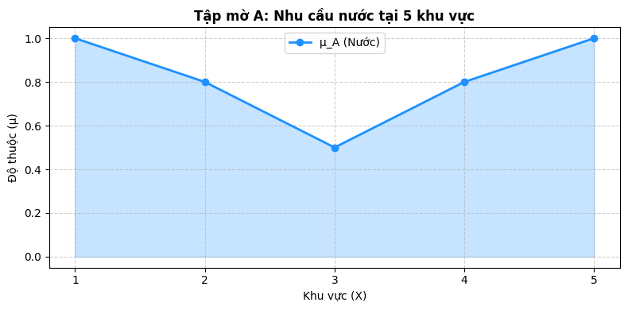

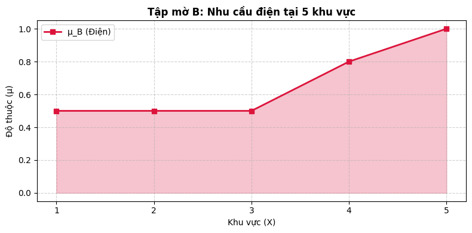

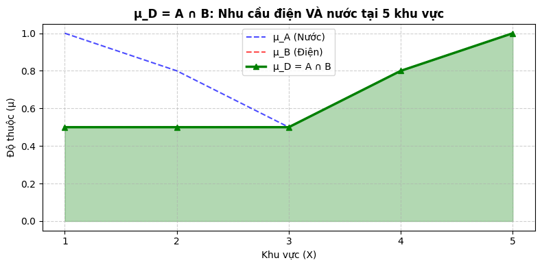

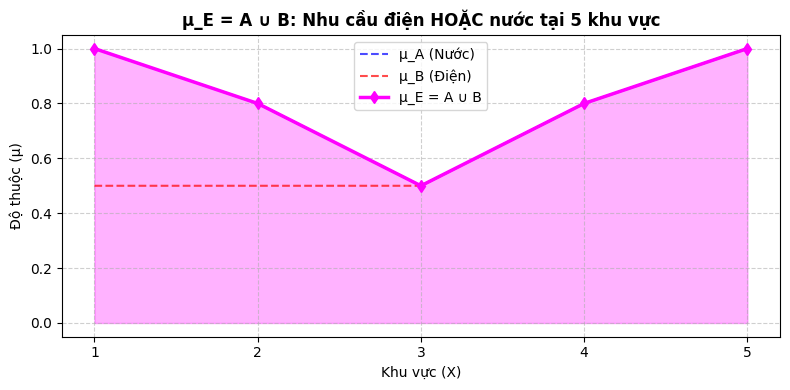

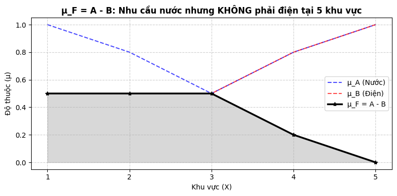

```python
import numpy as np
import matplotlib.pyplot as plt

# ===== 1. KHÔNG GIAN NỀN =====
X = np.array([1, 2, 3, 4, 5], dtype=float)

# ===== 2. TẬP MỜ GỐC =====
muA = np.array([1.0, 0.8, 0.5, 0.8, 1.0])  # A: Nhu cầu nước
muB = np.array([0.5, 0.5, 0.5, 0.8, 1.0])  # B: Nhu cầu điện

# ===== 3. TẬP MỜ THEO PHÉP TOÁN MỜ =====
muD = np.minimum(muA, muB)              # D = A ∩ B: điện VÀ nước
muE = np.maximum(muA, muB)              # E = A ∪ B: điện HOẶC nước
muF = np.minimum(muA, 1 - muB)          # F = A - B: nước nhưng KHÔNG phải điện

# ===== 4. CẤU HÌNH CHUNG =====
plt.rcParams['axes.unicode_minus'] = False

def ve_fuzzy(X, mu, label, title, color, marker='o'):
    plt.figure(figsize=(8, 4))
    plt.plot(X, mu, color=color, marker=marker, linestyle='-', linewidth=2, label=label)
    plt.fill_between(X, mu, 0, alpha=0.25, color=color)
    plt.title(title, fontsize=12, fontweight='bold')
    plt.xlabel("Khu vực (X)")
    plt.ylabel("Độ thuộc (μ)")
    plt.xticks(X)
    plt.yticks(np.arange(0, 1.1, 0.2))
    plt.grid(True, linestyle='--', alpha=0.6)
    plt.legend()
    plt.tight_layout()
    plt.show()

# ===== 5. VẼ TỪNG ĐỒ THỊ =====

# --- Đồ thị A: Nhu cầu nước ---
ve_fuzzy(X, muA, 'μ_A (Nước)',
         'Tập mờ A: Nhu cầu nước tại 5 khu vực', 'dodgerblue', marker='o')

# --- Đồ thị B: Nhu cầu điện ---
ve_fuzzy(X, muB, 'μ_B (Điện)',
         'Tập mờ B: Nhu cầu điện tại 5 khu vực', 'crimson', marker='s')

# --- Đồ thị D = A ∩ B ---
plt.figure(figsize=(8, 4))
plt.plot(X, muA, 'b--', label='μ_A (Nước)', alpha=0.7)
plt.plot(X, muB, 'r--', label='μ_B (Điện)', alpha=0.7)
plt.plot(X, muD, color='green', marker='^', linestyle='-', linewidth=2.5, label='μ_D = A ∩ B')
plt.fill_between(X, muD, 0, alpha=0.3, color='green')
plt.title("μ_D = A ∩ B: Nhu cầu điện VÀ nước tại 5 khu vực", fontsize=12, fontweight='bold')
plt.xlabel("Khu vực (X)"); plt.ylabel("Độ thuộc (μ)")
plt.xticks(X); plt.yticks(np.arange(0, 1.1, 0.2))
plt.grid(True, linestyle='--', alpha=0.6); plt.legend(); plt.tight_layout()
plt.show()

# --- Đồ thị E = A ∪ B ---
plt.figure(figsize=(8, 4))
plt.plot(X, muA, 'b--', label='μ_A (Nước)', alpha=0.7)
plt.plot(X, muB, 'r--', label='μ_B (Điện)', alpha=0.7)
plt.plot(X, muE, color='magenta', marker='d', linestyle='-', linewidth=2.5, label='μ_E = A ∪ B')
plt.fill_between(X, muE, 0, alpha=0.3, color='magenta')
plt.title("μ_E = A ∪ B: Nhu cầu điện HOẶC nước tại 5 khu vực", fontsize=12, fontweight='bold')
plt.xlabel("Khu vực (X)"); plt.ylabel("Độ thuộc (μ)")
plt.xticks(X); plt.yticks(np.arange(0, 1.1, 0.2))
plt.grid(True, linestyle='--', alpha=0.6); plt.legend(); plt.tight_layout()
plt.show()

# --- Đồ thị F = A - B ---
plt.figure(figsize=(8, 4))
plt.plot(X, muA, 'b--', label='μ_A (Nước)', alpha=0.7)
plt.plot(X, muB, 'r--', label='μ_B (Điện)', alpha=0.7)
plt.plot(X, muF, color='black', marker='*', linestyle='-', linewidth=2.5, label='μ_F = A - B')
plt.fill_between(X, muF, 0, alpha=0.3, color='gray')
plt.title("μ_F = A - B: Nhu cầu nước nhưng KHÔNG phải điện tại 5 khu vực", fontsize=12, fontweight='bold')
plt.xlabel("Khu vực (X)"); plt.ylabel("Độ thuộc (μ)")
plt.xticks(X); plt.yticks(np.arange(0, 1.1, 0.2))
plt.grid(True, linestyle='--', alpha=0.6); plt.legend(); plt.tight_layout()
plt.show()
```

## Bài 7. Mô tả mức tải dữ liệu mạng LAN bằng tập mờ

Xét một mạng cục bộ (LAN) gồm các máy trạm liên kết với nhau bằng giao thức Ethernet với tốc độ tối đa 10 Mbps. Lưu lượng trên mạng được biểu diễn bằng giá trị đỉnh của tổng băng thông sử dụng.

Hai tập mờ **"Quiet"** và **"Congested"** được dùng để mô tả mức tải dữ liệu cảm nhận được trên mạng LAN.

Nếu tập nền rời rạc: $$X = \{0, 1, 2, 5, 7, 9, 10\}$$ biểu diễn mức sử dụng băng thông (Mbps), thì membership functions của hai tập mờ $\tilde{Q}$ (Quiet) và $\tilde{C}$ (Congested) được cho trong Hình P2.7.

[figure not shown]

**Đối với các tập mờ này, hãy tìm bằng đồ họa:**

- Phép hợp: $\tilde{Q} \cup \tilde{C}$
- Phép giao: $\tilde{Q} \cap \tilde{C}$
- Phần bù của mỗi tập: $\overline{\tilde{Q}}$, $\overline{\tilde{C}}$
- Phép hiệu: $\tilde{Q} - \tilde{C}$, $\tilde{C} - \tilde{Q}$

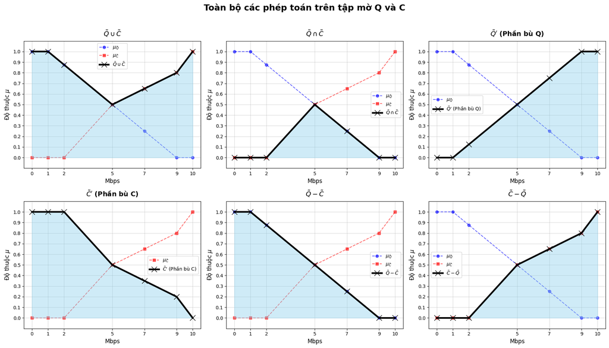

```python
import matplotlib.pyplot as plt
import numpy as np

# Cấu hình font để hiển thị tiếng Việt và ký tự toán học tốt hơn
plt.rcParams['font.family'] = 'sans-serif'
plt.rcParams['font.sans-serif'] = ['Arial', 'Tahoma', 'DejaVu Sans']

# 1. Dữ liệu đầu vào
X = np.array([0, 1, 2, 5, 7, 9, 10])
Q = np.array([1.0, 1.0, 0.875, 0.5, 0.25, 0.0, 0.0])
C = np.array([0.0, 0.0, 0.0, 0.5, 0.65, 0.8, 1.0])

# 2. Tính toán toàn bộ các phép toán
union = np.maximum(Q, C)
inter = np.minimum(Q, C)

comp_Q = 1 - Q
comp_C = 1 - C

diff_Q_C = np.minimum(Q, 1 - C)  # Q - C = min(Q, 1-C)
diff_C_Q = np.minimum(C, 1 - Q)  # C - Q = min(C, 1-Q)

# 3. Tạo lưới đồ thị 2x3
fig, axes = plt.subplots(2, 3, figsize=(18, 10))
fig.suptitle('Toàn bộ các phép toán trên tập mờ Q và C', fontsize=18, fontweight='bold', y=1.02)

# Danh sách các phép toán để duyệt qua
# (Dữ liệu kết quả, Tiêu đề, Hiển thị tập Q, Hiển thị tập C)
operations = [
    (union, r'$\tilde{Q} \cup \tilde{C}$', True, True),
    (inter, r'$\tilde{Q} \cap \tilde{C}$', True, True),
    (comp_Q, r"$\tilde{Q}'$ (Phần bù Q)", True, False),
    (comp_C, r"$\tilde{C}'$ (Phần bù C)", False, True),
    (diff_Q_C, r'$\tilde{Q} - \tilde{C}$', True, True),
    (diff_C_Q, r'$\tilde{C} - \tilde{Q}$ ', True, True)
]

# Biến đếm vị trí trong lưới 2x3
idx = 0

for i in range(2):
    for j in range(3):
        ax = axes[i, j]
        res_data, title, show_Q, show_C = operations[idx]

        # --- Vẽ tập gốc (Đường đứt nét) ---
        if show_Q:
            ax.plot(X, Q, 'b--', marker='o', label=r'$\mu_{\tilde{Q}}$', alpha=0.6, linewidth=1.5)
        if show_C:
            ax.plot(X, C, 'r--', marker='s', label=r'$\mu_{\tilde{C}}$', alpha=0.6, linewidth=1.5)

        # --- Vẽ kết quả (Đường đen đậm + Tô màu) ---
        ax.plot(X, res_data, 'k-', linewidth=3.5, marker='x', markersize=12, label=title, zorder=3)
        ax.fill_between(X, 0, res_data, color='skyblue', alpha=0.4, zorder=2)

        # --- Cấu hình trục và chú thích ---
        ax.set_xticks(X)
        ax.set_yticks(np.arange(0, 1.1, 0.1))
        ax.set_ylim(-0.1, 1.1)
        ax.grid(True, linestyle='-', alpha=0.5)
        ax.set_xlabel('Mbps', fontsize=12)
        ax.set_ylabel(r'Độ thuộc $\mu$', fontsize=12)
        ax.legend(loc='best', fontsize=10)
        ax.set_title(title, fontsize=14, fontweight='bold', pad=10)

        idx += 1

plt.tight_layout()
plt.show()
```

# Bài 8

Một kỹ sư được yêu cầu phát triển bộ phát hiện/phân biệt kính vỡ để sử dụng trong hệ thống báo động dân dụng.

Thiết bị phải có khả năng phân biệt:

- Âm thanh kính cửa sổ bị vỡ
- Âm thanh ly thủy tinh bị vỡ

Qua phân tích, người ta xác định rằng:

- Âm thanh kính cửa sổ bị vỡ chứa phần lớn năng lượng tại tần số khoảng **4 kHz**
- Âm thanh ly thủy tinh bị vỡ chứa phần lớn năng lượng tại tần số khoảng **8 kHz**

Phổ tần số của hai âm thanh này có sự chồng lấp. Các hàm thuộc (membership functions) cho kính cửa sổ và ly thủy tinh lần lượt là: $\mu_A(x)$, $\mu_B(x)$.

**Cho:**

- $X = \{0, 1, \dots, 10\}$
- $\sigma = 2$
- $\mu_A = 4$, $\mu_B = 8$

$$ \mu_A(x) = \exp\left(-\frac{(x - \mu_A)^2}{2\sigma^2}\right), \quad \mu_B(x) = \exp\left(-\frac{(x - \mu_B)^2}{2\sigma^2}\right) $$

**Yêu cầu:** Hãy minh họa các phép toán cơ bản trên tập mờ cho các hàm thuộc trên:

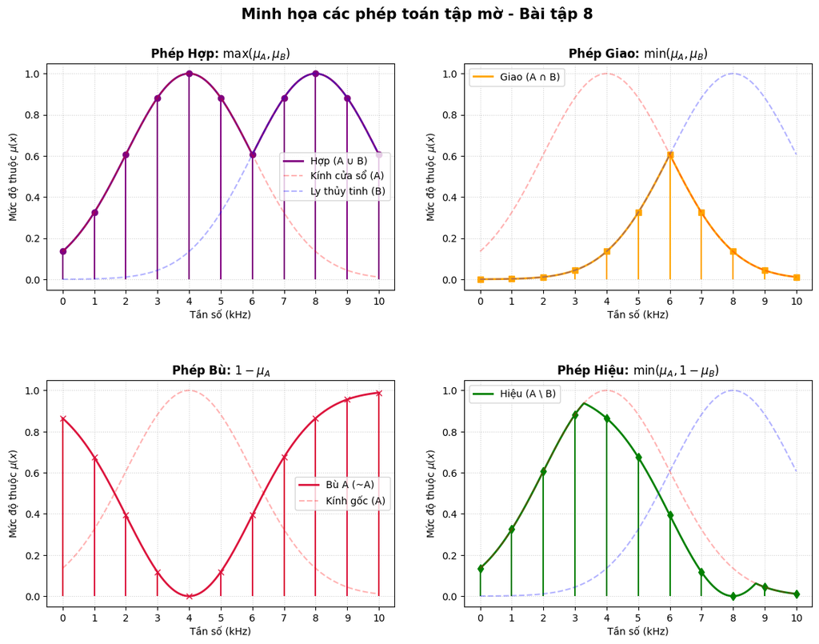

```python
import numpy as np
import matplotlib.pyplot as plt

# 1. Định nghĩa tập nền rời rạc X theo đề bài
x_discrete = np.arange(0, 11)

# Tạo mảng x mịn để vẽ đường đồ thị nền liên tục giúp trực quan hơn
x_smooth = np.linspace(0, 10, 500)

def gauss_mf(x, mu, sigma=2):
    return np.exp(-0.5 * ((x - mu) / sigma)**2)

# Tính toán giá trị hàm thuộc cho cả dạng mịn và dạng rời rạc
mu_A_smooth = gauss_mf(x_smooth, mu=4)
mu_B_smooth = gauss_mf(x_smooth, mu=8)

mu_A_disc = gauss_mf(x_discrete, mu=4)
mu_B_disc = gauss_mf(x_discrete, mu=8)

# Thiết lập hệ thống khung đồ thị gồm 4 ô (subplots)
fig, axes = plt.subplots(2, 2, figsize=(14, 10))
plt.subplots_adjust(hspace=0.4, wspace=0.2)

# --- Ô 1: Phép Hợp (Union) ---
axes[0, 0].plot(x_smooth, np.maximum(mu_A_smooth, mu_B_smooth), 'purple', lw=2, label='Hợp (A ∪ B)')
axes[0, 0].stem(x_discrete, np.maximum(mu_A_disc, mu_B_disc), linefmt='purple', markerfmt='o', basefmt=' ')
axes[0, 0].plot(x_smooth, mu_A_smooth, 'r--', alpha=0.3, label='Kính cửa sổ (A)')
axes[0, 0].plot(x_smooth, mu_B_smooth, 'b--', alpha=0.3, label='Ly thủy tinh (B)')
axes[0, 0].set_title('Phép Hợp: $\max(\mu_A, \mu_B)$', fontsize=12, fontweight='bold')
axes[0, 0].legend()

# --- Ô 2: Phép Giao (Intersection) ---
axes[0, 1].plot(x_smooth, np.minimum(mu_A_smooth, mu_B_smooth), 'orange', lw=2, label='Giao (A ∩ B)')
axes[0, 1].stem(x_discrete, np.minimum(mu_A_disc, mu_B_disc), linefmt='orange', markerfmt='s', basefmt=' ')
axes[0, 1].plot(x_smooth, mu_A_smooth, 'r--', alpha=0.3)
axes[0, 1].plot(x_smooth, mu_B_smooth, 'b--', alpha=0.3)
axes[0, 1].set_title('Phép Giao: $\min(\mu_A, \mu_B)$', fontsize=12, fontweight='bold')
axes[0, 1].legend()

# --- Ô 3: Phép Bù (Complement) ---
axes[1, 0].plot(x_smooth, 1 - mu_A_smooth, 'crimson', lw=2, label='Bù A (~A)')
axes[1, 0].stem(x_discrete, 1 - mu_A_disc, linefmt='crimson', markerfmt='x', basefmt=' ')
axes[1, 0].plot(x_smooth, mu_A_smooth, 'r--', alpha=0.3, label='Kính gốc (A)')
axes[1, 0].set_title('Phép Bù: $1 - \mu_A$', fontsize=12, fontweight='bold')
axes[1, 0].legend()

# --- Ô 4: Phép Hiệu (Difference: A \ B) ---
mu_diff_smooth = np.minimum(mu_A_smooth, 1 - mu_B_smooth)
mu_diff_disc = np.minimum(mu_A_disc, 1 - mu_B_disc)
axes[1, 1].plot(x_smooth, mu_diff_smooth, 'green', lw=2, label='Hiệu (A \\ B)')
axes[1, 1].stem(x_discrete, mu_diff_disc, linefmt='green', markerfmt='d', basefmt=' ')
axes[1, 1].plot(x_smooth, mu_A_smooth, 'r--', alpha=0.3)
axes[1, 1].plot(x_smooth, mu_B_smooth, 'b--', alpha=0.3)
axes[1, 1].set_title('Phép Hiệu: $\min(\mu_A, 1 - \mu_B)$', fontsize=12, fontweight='bold')
axes[1, 1].legend()

# Cấu hình định dạng hiển thị chung cho các đồ thị con
for ax in axes.flat:
    ax.set_xlim(-0.5, 10.5)
    ax.set_ylim(-0.05, 1.05)
    ax.set_xticks(x_discrete)
    ax.set_xlabel('Tần số (kHz)')
    ax.set_ylabel('Mức độ thuộc $\mu(x)$')
    ax.grid(True, linestyle=':', alpha=0.6)

plt.suptitle('Minh họa các phép toán tập mờ - Bài tập 8', fontsize=15, fontweight='bold', y=0.96)
plt.show()
```

# Bài 2

Trên cơ sở 2 tập mờ $A$: phòng học rộng, $B$: phòng có thể chứa 100 sinh viên, xây dựng các tập mờ:

- $D$: Các phòng học rộng mà chỉ chứa khoảng 100 sinh viên ($A \cap B$)
- $E$: Các phòng học rộng hoặc có thể chứa 100 sinh viên ($A \cup B$)
- $F$: Các phòng học không rộng ($\neg A$)

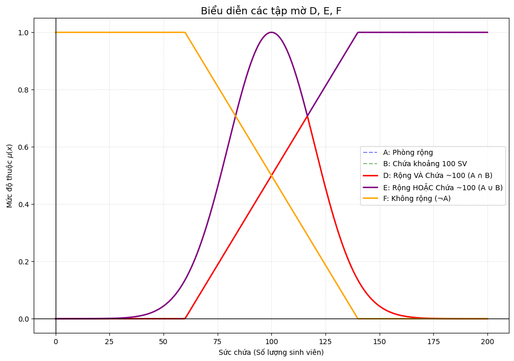

```python
import numpy as np
import matplotlib.pyplot as plt

# 1. Định nghĩa không gian nền x (Số lượng sinh viên từ 0 đến 200)
x = np.linspace(0, 200, 500)

# 2. Định nghĩa hàm thuộc cho các tập mờ cơ sở
# Tập A: Phòng rộng (giả sử rộng bắt đầu từ 60 chỗ và đạt mức 1 tại 140 chỗ)
mu_A = np.clip((x - 60) / (140 - 60), 0, 1)

# Tập B: Chứa khoảng 100 sinh viên (dùng hàm Gaussian centered at 100)
mu_B = np.exp(-0.5 * ((x - 100) / 20)**2)

# 3. Tính toán các tập mờ theo yêu cầu bài tập
mu_D = np.minimum(mu_A, mu_B)  # Giao (A ∩ B)
mu_E = np.maximum(mu_A, mu_B)  # Hợp (A ∪ B)
mu_F = 1 - mu_A                # Phủ định (¬A)

# 4. Vẽ biểu đồ
plt.figure(figsize=(12, 8))

# Vẽ A và B (nền)
plt.plot(x, mu_A, 'b--', label='A: Phòng rộng', alpha=0.5)
plt.plot(x, mu_B, 'g--', label='B: Chứa khoảng 100 SV', alpha=0.5)

# Vẽ các kết quả
plt.plot(x, mu_D, 'red', linewidth=2, label='D: Rộng VÀ Chứa ~100 (A ∩ B)')
plt.plot(x, mu_E, 'purple', linewidth=2, label='E: Rộng HOẶC Chứa ~100 (A ∪ B)')
plt.plot(x, mu_F, 'orange', linewidth=2, label='F: Không rộng (¬A)')

# Định dạng biểu đồ
plt.title('Biểu diễn các tập mờ D, E, F', fontsize=14)
plt.xlabel('Sức chứa (Số lượng sinh viên)')
plt.ylabel('Mức độ thuộc $\mu(x)$')
plt.legend()
plt.grid(True, linestyle=':', alpha=0.6)
plt.axhline(0, color='black', lw=1)
plt.axvline(0, color='black', lw=1)

plt.show()
```

# Bài 3

Xây dựng các tập mờ sau để bổ sung thêm căn cứ xét tuyển vào một trường đại học ngoài điểm của học bạ:

- Thư giới thiệu của giáo viên
- Bài luận giới thiệu về bản thân
- Một số bài luận khác

```python
import numpy as np
import matplotlib.pyplot as plt

universe = np.array([0, 1, 2, 3, 4, 5, 6, 7, 8, 9, 10])

# Các tập mờ rời rạc (định dạng: phần tử/độ thuộc)
A = np.array([0,   0,   0,   0,   0,   0,   0,   0,   0.7, 1.0, 1.0])  # Thư giới thiệu
B = np.array([0,   0,   0,   0,   0,   0,   0,   0, 0.5, 1.0, 1.0])  # Bài luận bản thân
C = np.array([0,   0,   0,   0,   0,   0,   0,   0.4, 0.8, 0.9, 1.0])  # Bài luận khác
D = np.array([0,   0,   0.2, 0.4, 0.6, 0.8, 1.0, 1.0, 1.0, 1.0, 1.0])  # Điểm cộng

intersection = np.minimum(np.minimum(A, B), np.minimum(C, D))

# =============================================================================
# 3. IN BẢNG KẾT QUẢ
# =============================================================================
print("="*90)
print("BẢNG GIÁ TRỊ ĐỘ THUỘC VÀ KẾT QUẢ GIAO A  B ∩ C ∩ D")
print("="*90)
print(f"{'Điểm (x)':<10} | {'μA(x)':<8} | {'μB(x)':<8} | {'μC(x)':<8} | {'μD(x)':<8} | {'μ_∩(x)':<8}")
print("-"*90)
for i, x in enumerate(universe):
    print(f"{x:<10} | {A[i]:<8.2f} | {B[i]:<8.2f} | {C[i]:<8.2f} | {D[i]:<8.2f} | {intersection[i]:<8.2f}")
print("="*90)

# =============================================================================
# 4. VẼ ĐỒ THỊ
# =============================================================================
fig, axes = plt.subplots(2, 3, figsize=(16, 9))
axes = axes.flatten()

def plot_discrete_fuzzy(ax, x, y, title, color, show_dots=True):
    """Hàm vẽ tập mờ rời rạc"""
    ax.plot(x, y, marker='o', linestyle='-', color=color, linewidth=2, markersize=7)
    if show_dots:
        ax.vlines(x, 0, y, colors=color, linestyles='dashed', alpha=0.4)
    ax.set_title(title, fontsize=13, fontweight='bold', pad=10)
    ax.set_xlabel('Điểm (x)', fontsize=11)
    ax.set_ylabel('Độ thuộc μ(x)', fontsize=11)
    ax.set_xticks(x)
    ax.set_xticklabels([f'{v}' for v in x], rotation=45, ha='right')
    ax.set_ylim(-0.1, 1.15)
    ax.grid(True, linestyle=':', alpha=0.6)
    # Chú thích giá trị tại các điểm > 0
    for xi, yi in zip(x, y):
        if yi > 0:
            ax.annotate(f'{yi:.1f}', xy=(xi, yi), xytext=(0, 6),
                        textcoords='offset points', ha='center', color=color, fontweight='bold')

# Vẽ 4 tập mờ riêng biệt
plot_discrete_fuzzy(axes[0], universe, A, 'Tập mờ A: Thư giới thiệu', 'blue')
plot_discrete_fuzzy(axes[1], universe, B, 'Tập mờ B: Bài luận bản thân', 'green')
plot_discrete_fuzzy(axes[2], universe, C, 'Tập mờ C: Một số bài luận khác', 'orange')
plot_discrete_fuzzy(axes[3], universe, D, 'Tập mờ D: Điểm cộng', 'purple')

# Vẽ đồ thị giao A ∩ B ∩ C ∩ D
plot_discrete_fuzzy(axes[4], universe, intersection, 'GIAO: A ∩ B ∩ C ∩ D', 'red')
# Vẽ mờ các tập gốc để so sánh
for arr, col, lab in zip([A,B,C,D], ['blue','green','orange','purple'], ['A','B','C','D']):
    axes[4].plot(universe, arr, marker='x', linestyle='--', color=col, alpha=0.3, label=f'{lab}')
axes[4].legend(loc='upper left', fontsize=9)

# Ẩn ô thừa
axes[5].axis('off')

plt.tight_layout()
plt.show()
```

[output not shown]

```
==========================================================================================
BẢNG GIÁ TRỊ ĐỘ THUỘC VÀ KẾT QUẢ GIAO A  B ∩ C ∩ D
==========================================================================================
Điểm (x)   | μA(x)    | μB(x)    | μC(x)    | μD(x)    | μ_∩(x)
------------------------------------------------------------------------------------------
0          | 0.00     | 0.00     | 0.00     | 0.00     | 0.00
1          | 0.00     | 0.00     | 0.00     | 0.00     | 0.00
2          | 0.00     | 0.00     | 0.00     | 0.20     | 0.00
3          | 0.00     | 0.00     | 0.00     | 0.40     | 0.00
4          | 0.00     | 0.00     | 0.00     | 0.60     | 0.00
5          | 0.00     | 0.00     | 0.00     | 0.80     | 0.00
6          | 0.00     | 0.00     | 0.00     | 1.00     | 0.00
7          | 0.00     | 0.00     | 0.40     | 1.00     | 0.00
8          | 0.70     | 0.50     | 0.80     | 1.00     | 0.50
9          | 1.00     | 1.00     | 0.90     | 1.00     | 0.90
10         | 1.00     | 1.00     | 1.00     | 1.00     | 1.00
==========================================================================================
```

# Bài 4:

Để giám định một viên đá quý, người ta căn cứ vào trọng lượng, kích thước và độ tinh khiết, giả sử không gian nền như sau:

Trọng lượng: có tập tham chiếu X ⊂ R+ tính bằng cara

Kích thước: tập tham chiếu là Y={1,2,3}

Độ tinh khiết cũng có tập tham chiếu là Z={1,5,10}

Tập mờ giá tốt (G) của viên đá quý phải dựa trên 3 yếu tố; chẳng hạn: trọng lượng hợp lý (A), kích thước phù hợp (B), độ tinh khiết cao (C)

Với G = A x B x C trên không gian nền là X x Y x Z

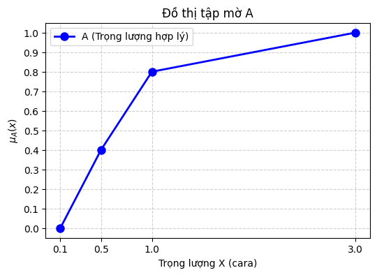

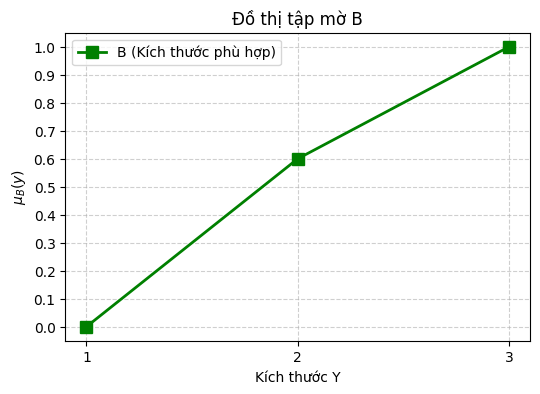

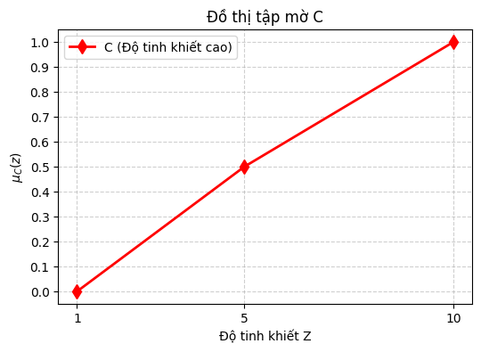

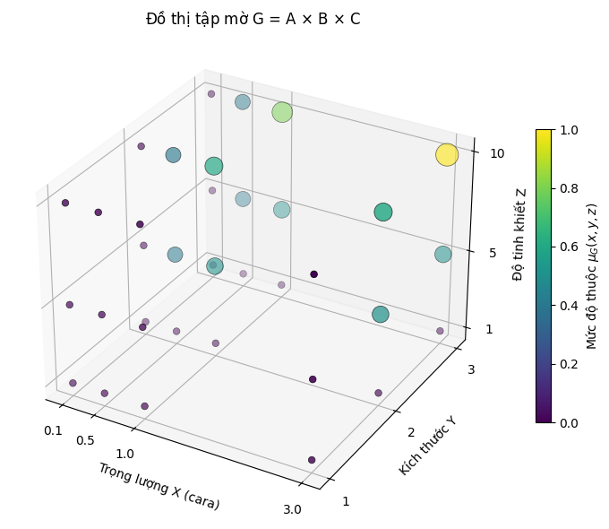

```python
import numpy as np
import matplotlib.pyplot as plt

# ==========================================
# 1. ĐỊNH NGHĨA KHÔNG GIAN NỀN & HÀM THUỘC
# ==========================================
X = np.array([0.1, 0.5, 1.0, 3.0])
mu_A = np.array([0.0, 0.4, 0.8, 1.0])

Y = np.array([1, 2, 3])
mu_B = np.array([0.0, 0.6, 1.0])

Z = np.array([1, 5, 10])
mu_C = np.array([0.0, 0.5, 1.0])

# ==========================================
# 2. VẼ ĐỒ THỊ RIÊNG CHO A, B, C
# ==========================================
# Đồ thị A
plt.figure(figsize=(6, 4))
plt.plot(X, mu_A, 'o-', color='blue', markersize=8, linewidth=2, label='A (Trọng lượng hợp lý)')
plt.title(r'Đồ thị tập mờ A')
plt.xlabel('Trọng lượng X (cara)')
plt.ylabel(r'$\mu_A(x)$')
plt.xticks(X)
plt.yticks(np.arange(0, 1.1, 0.1))
plt.ylim(-0.05, 1.05)
plt.grid(True, linestyle='--', alpha=0.6)
plt.legend()
plt.show()

# Đồ thị B
plt.figure(figsize=(6, 4))
plt.plot(Y, mu_B, 's-', color='green', markersize=8, linewidth=2, label='B (Kích thước phù hợp)')
plt.title(r'Đồ thị tập mờ B')
plt.xlabel('Kích thước Y')
plt.ylabel(r'$\mu_B(y)$')
plt.xticks(Y)
plt.yticks(np.arange(0, 1.1, 0.1))
plt.ylim(-0.05, 1.05)
plt.grid(True, linestyle='--', alpha=0.6)
plt.legend()
plt.show()

# Đồ thị C
plt.figure(figsize=(6, 4))
plt.plot(Z, mu_C, 'd-', color='red', markersize=8, linewidth=2, label='C (Độ tinh khiết cao)')
plt.title(r'Đồ thị tập mờ C')
plt.xlabel('Độ tinh khiết Z')
plt.ylabel(r'$\mu_C(z)$')
plt.xticks(Z)
plt.yticks(np.arange(0, 1.1, 0.1))
plt.ylim(-0.05, 1.05)
plt.grid(True, linestyle='--', alpha=0.6)
plt.legend()
plt.show()

# ==========================================
# 3. TÍNH TOÁN & VẼ ĐỒ THỊ G = A x B x C
# ==========================================
# Tích Descartes mờ dùng phép min (phép giao chuẩn Zadeh)
Xg, Yg, Zg = np.meshgrid(X, Y, Z, indexing='ij')
mu_G = np.minimum(np.minimum(mu_A[:, None, None], mu_B[None, :, None]), mu_C[None, None, :])

# Làm phẳng mảng 3D thành 1D để vẽ
x_flat = Xg.flatten()
y_flat = Yg.flatten()
z_flat = Zg.flatten()
mu_flat = mu_G.flatten()

fig = plt.figure(figsize=(9, 6))
ax = fig.add_subplot(111, projection='3d')

# Vẽ scatter 3D:
# - 3 trục tọa độ: X, Y, Z
# - Màu sắc & kích thước điểm biểu diễn mức độ thuộc μ_G
scatter = ax.scatter(x_flat, y_flat, z_flat, c=mu_flat, cmap='viridis',
                     s=mu_flat*300 + 30, edgecolors='black', linewidth=0.5, depthshade=True)
fig.colorbar(scatter, ax=ax, label=r'Mức độ thuộc $\mu_G(x,y,z)$', shrink=0.6)

# Trang trí đồ thị G
ax.set_xlabel('Trọng lượng X (cara)', fontsize=10)
ax.set_ylabel('Kích thước Y', fontsize=10)
ax.set_zlabel('Độ tinh khiết Z', fontsize=10)
ax.set_title(r'Đồ thị tập mờ G = A $\times$ B $\times$ C', fontsize=12)
ax.set_xticks(X)
ax.set_yticks(Y)
ax.set_zticks(Z)
ax.grid(True, alpha=0.3)
plt.tight_layout()
plt.show()
```

```python
!jupyter nbconvert --to html 'BaiTap2 - Phep toan tren tap mo'.ipynb
```

[output not shown]

[output cut: 142 more lines]

[output not shown]